# Urchin Populations in Santa Barbara Reefs

Margaret Hammond

10/26/2021

## Overview

Sea urchin populations in 5 different reefs in Santa Barbara: Naples Reef, Arroyo Quemado Reef, Carpinteria Reef, Mohawk Reef, and Isla Vista Reef. This data holds information on the size frequency distribution of red and purple sea urchins from 2008 - 2020. The data is analyzed to determine the difference of size between red and purple sea urchins, and if the sea urchin population is decreasing among the sites.

## Citation

Data: Reed, D. 2020. SBC LTER: Reef: Long-term experiment: Kelp removal: Urchin size frequency distribution ver 20. Environmental Data Initiative. https://doi.org/10.6073/pasta/5a1e9ef03aa47bd2225c0bb98a02a63b.

```r
knitr::opts_chunk$set(echo = TRUE)
library(tidyverse)
library(kableExtra)
library(here)
library(janitor)
library(lubridate)
```

## Read in Data

```r
urchins <- read_csv(here("data", "urchins.csv"))
urchins_clean <- urchins %>% clean_names()
```

## Data Visualization

Histogram to compare the sizes of red and purple sea urchin populations in Santa Barbara reefs. Bins lowered to 10 per urchin type for cleaner organization.

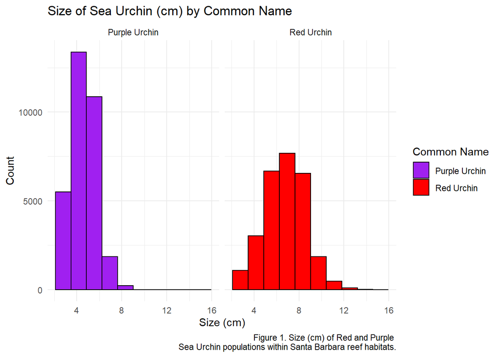

```r
ggplot(data = urchins_clean, aes(x = size)) +
  geom_histogram(bins = 10, # Less bins for proper organization
                 aes(fill = common_name),
                 color = "black") +
  scale_fill_manual(values = c("purple", "red")) + # Assign the correct colors to histogram
  facet_wrap(~ common_name) + # Wrap by common name for data comparison
  labs(x = "Size (cm)",
       y = "Count",
       title = "Size of Sea Urchin (cm) by Common Name",
       fill = "Common Name",
       caption = "Figure 1. Size (cm) of Red and Purple
       Sea Urchin populations within Santa Barbara reef habitats.") +
  theme_minimal()
```

## Statistics Table

Summary table that shows the statistics for purple and red urchins. Includes mean, median, standard deviation, and sample size. This is to understand the data statistics and compare the sizes between the two urchin populations.

```r
urchin_stats <- urchins_clean %>%
  group_by(common_name) %>% # Group by purple or red urchin
  summarize(mean_size_cm = round(mean(size), 2), # Round to the 2 decimal places for organization
            median_size_cm = median(size),
            sd_size_cm = round(sd(size), 2), # Round to the 2 decimal places for organization
            sample_size = n())

urchin_stats %>%
  kable(col.names = c("Common Name", # Create correct column labels
                      "Mean size (cm)",
                      "Median size (cm)",
                      "Standard deviation (cm)",
                      "Sample size (n)"),
        caption = "Figure 2. Sea Urchin Size (cm) Statistics Summary by Common Name") %>%
  kable_styling(full_width = TRUE)
```

Figure 2. Sea Urchin Size (cm) Statistics Summary by Common Name

| Common Name | Mean size (cm) | Median size (cm) | Standard deviation (cm) | Sample size (n) |
| --- | --- | --- | --- | --- |
| Purple Urchin | 4.47 | 4.5 | 1.18 | 31805 |
| Red Urchin | 6.78 | 7.0 | 1.89 | 27408 |

## Purple Urchin Data Creation

Create a separate data set of purple urchins. In this data set, date is cleaned up to be in proper R format, and a new column `year` is created. Column `site_full` created to give the full names of the site collection spots.

```r
purple_urchins <- urchins_clean %>%
  filter(common_name == "Purple Urchin") %>% # Filter by purple urchin to only contain that data
  mutate(date = mdy(date)) %>%  # Use mdy() to convert data to Date class
  mutate(year = year(date)) %>%
  mutate(site_full = case_when( # Create site_full column of proper reef names
    site == "NAPL" ~ "Naples Reef",
    site == "AQUE" ~ "Arroyo Quemado Reef",
    site == "CARP" ~ "Carpinteria Reef",
    site == "MOHK" ~ "Mohawk Reef",
    site == "IVEE" ~ "Isla Vista Reef"
  ))
```

## Table Set Up

Creating the code for a table to show the total number of purple urchins observed by site and year.

```r
purple_urchins_table <- purple_urchins %>%
  count(site_full, year)
```

## Graph of Purple Urchins

Make a finalized graph of counts of purple urchins recorded at each site over time for the years included in the study.

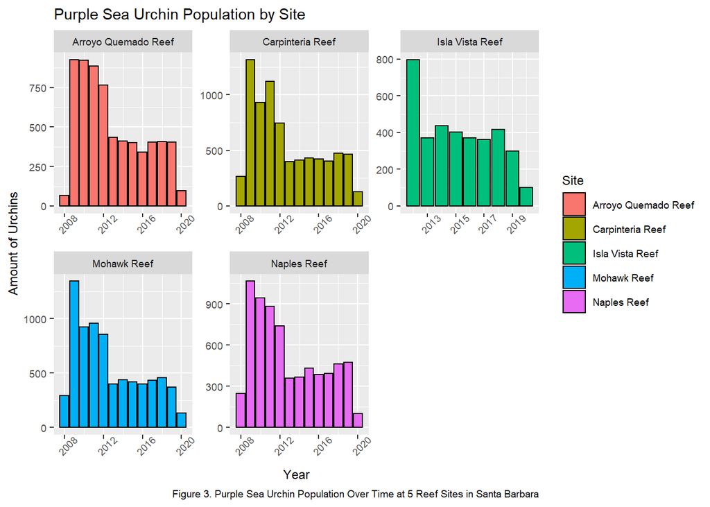

```r
ggplot(data = purple_urchins_table, aes(x = year, y = n)) +
 geom_bar(aes(fill = site_full),
          stat = "identity", color = "black") + # Bar plot to compare populations
  facet_wrap(~ site_full, scale = "free") + # Facet_wrap for site comparison
  theme(text = element_text(
    size = 9)) +
      theme(axis.text.x = element_text(angle = 45)) + # Tilt the axis labels for organization
  labs(x = "Year",
       y = "Amount of Urchins",
       title = "Purple Sea Urchin Population by Site",
       fill = "Site",
       caption = "Figure 3. Purple Sea Urchin Population Over Time at 5 Reef Sites in Santa Barbara")
```

## Data Analysis

This graph shows a decline of purple sea urchin populations at all sites during the final years of observation. This may not be reflective of the total purple sea urchin population, because the sea urchins may be moving to other, unrecorded sites. We cannot make conclusions about the total population decline without understanding possible habitat changes and population dynamics.

### End of Task 3